# part1-esc-knitable

South Coast StA

Last update: 2024-06-11 12:22

# 1 **Abundance and biodata**

Status snapshot:

- Chinook enhancement began 1978
- Recent 12-yr average adult escapement (incl broodstock): 1670
  - Range: 591 - 4133
- Recent 4-yr avg adult escapement (incl broodstock): 1583
  - Range: 911 - 3007
- Long-term age structure (entire time series): 4 year olds (47.4 +/- 23.9%) followed by 5 year olds (31.1 +/- 22.8%)
- Recent (12yr) dominant age structure: 4 year olds (59.6 +/- 17%) followed by 3 year olds (23 +/- 12.6%)
- Hatchery vs wild: uncertain due to historical marking/tagging process. Mostly unclipped with no thermal mark (but historical TM process highly unreliable)

## 1.1 Escapement

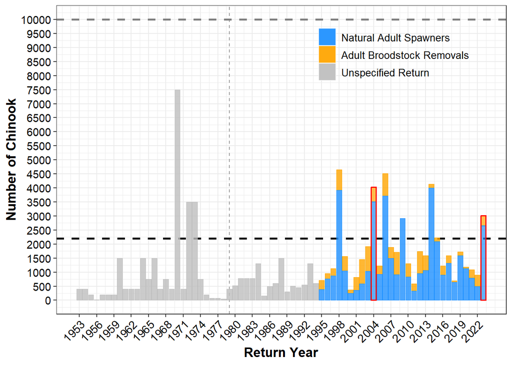

Figure 1.1: Spawners and broodstock removals for San Juan Chinook, specific adults only where known. Vertical dashed gray line(s) indicate periods of enhancement. Horizontal dashed black line indicates habitat-model based Smsy estimate. Data from NuSEDS; red outlined bars (if any) indicate escapement estimates not in NuSEDS.

### 1.1.1 Escapement goals

The current escapement goals developed by Holt et al. based on a habitat model (Parken et al 2008), which are estimates of individual fish (not spawning pairs - requires assumptions about sex ratios to infer juvenile output):

- Smsy: 2200 (1200-4100) - The escapement required to produce maximum sustainable yield
- Sgen: 990 (250-3100) - The escapement required to recover to Smsy in 1 generation
- Srep: 5200 (2900-9300) - System capacity

Additional benchmarks for use:

- Fish Stock Provisions Rebuilding goal (Sgen * 1.5) = 1485
- Pacheedaht/Burt habitat capacity estimate = 10,000 spawning pairs
- Pacheedaht Rebuilding Goal: 5,000

## 1.2 Run timing

Most chinook are observed in the San Juan between late September (statweek 94) and mid October (statweek 102) (Figure 1.2). Run timing counts come from a combination of the fence (which is usually in until Thanksgiving if possible) and swim surveys (which typically start after the fence is removed). Escapement estimates are typically derived from the swim surveys alone.

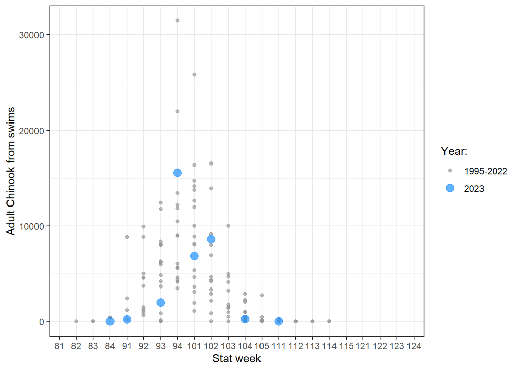

Figure 1.2: Chinook counts through the fence and/or swim surveys in the San Juan River from 1995-present. Counts are more representative of arrival rather than peak spawning. Stock Assessment data.

Daily fence counts have not been historically supplied except for the last three years (Fig 1.3).

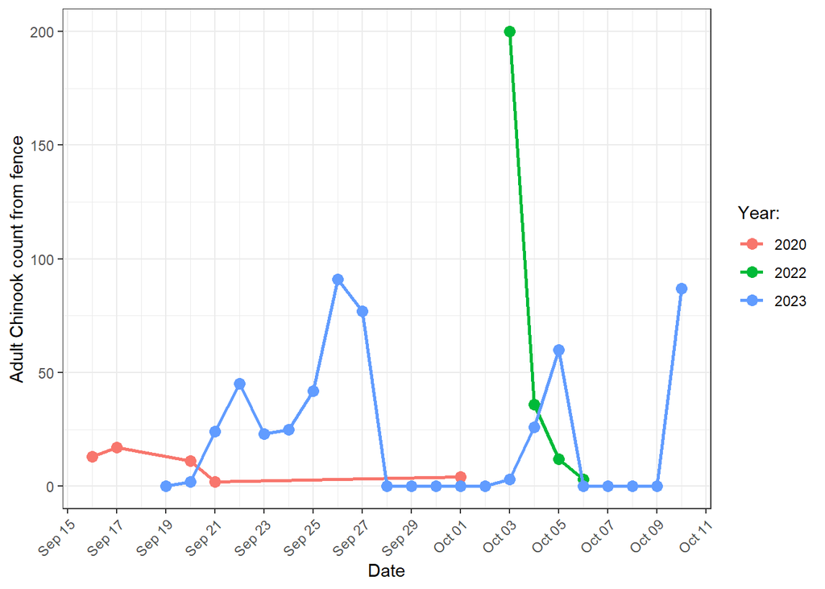

Figure 1.3: Chinook counts through the fence only in the San Juan River. Counts include fish kept for brood and released upstream of the fence. Data from 4 Mile Hatchery.

## 1.3 Upcoming return

The 2024 return will be composed of offspring from the following brood years:

| Return year | Escapement (spawners+broodstock) |
| --- | --- |
| 2018 | 700 |
| 2019 | 1,727 |
| 2020 | 1,179 |

## 1.4 Age structure

The adult age structure is primarily 4 and 5 year olds. Jacks and 6 year olds contribute almost nothing to the population, especially in recent years (see Table 1.2 and Figure 1.4). Biosample data are only obtained from hatchery broodstock; no deadpitch currently occurs on the naturally-spawning population

Table 1.2: Age structure of San Juan Chinook. Data from PADS (NuSEDS and MRPIS).

| PADS_Sample Source | Age | Proportion (avg) | +/- SD |
| --- | --- | --- | --- |
| ESCAPEMENT | 1 | 2.5 | NA |
| ESCAPEMENT | 2 | 2.0 | 1.3 |
| ESCAPEMENT | 3 | 24.9 | 24.8 |
| ESCAPEMENT | 4 | 45.0 | 24.1 |
| ESCAPEMENT | 5 | 31.1 | 20.9 |
| ESCAPEMENT | 6 | 4.6 | 7.2 |
| HATCHERY | 3 | 26.2 | NA |
| HATCHERY | 4 | 38.8 | NA |
| HATCHERY | 5 | 35.0 | NA |
| NATIVE FOOD FISHERY | 3 | 9.9 | 0.1 |
| NATIVE FOOD FISHERY | 4 | 67.7 | 3.2 |
| NATIVE FOOD FISHERY | 5 | 19.3 | 1.0 |
| NATIVE FOOD FISHERY | 6 | 6.2 | NA |
| NA | 3 | 36.8 | 8.1 |
| NA | 4 | 52.7 | 17.5 |
| NA | 5 | 10.3 | 9.2 |
| NA | 6 | 0.3 | NA |

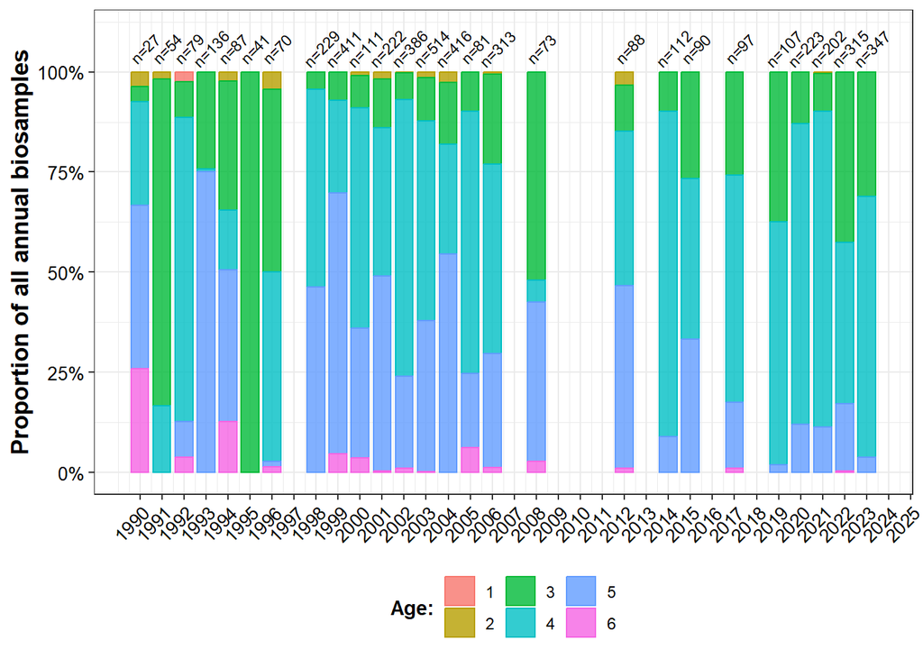

Figure 1.4: Annual age structure of San Juan Chinook. Numbers above bars indicate the number of samples contributing age data each year. Data from PADS (NuSEDS and MRPIS).

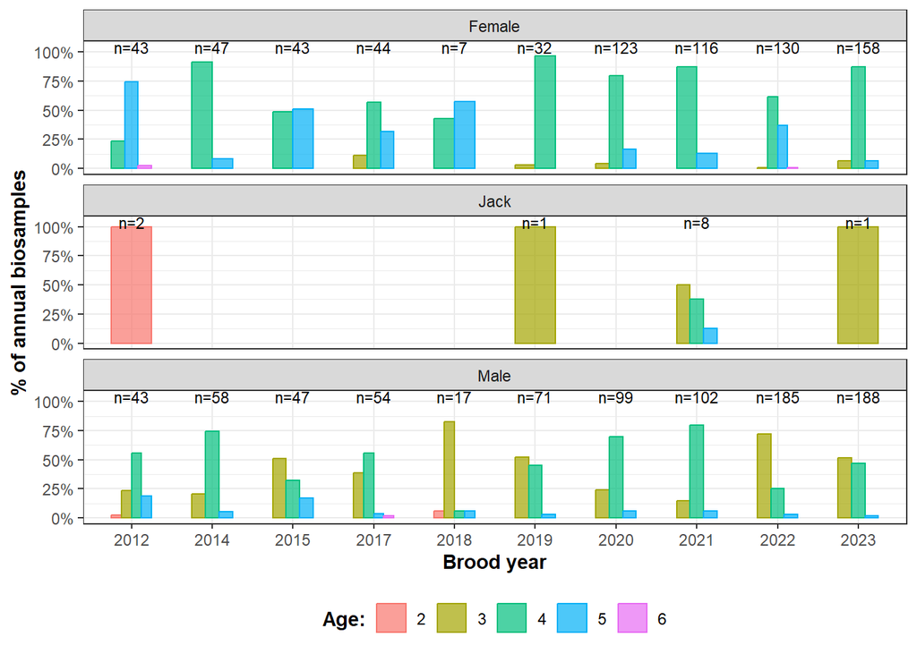

Figure 1.5: Annual age structure of San Juan Chinook by sex. Numbers above bars indicate the number of samples contributing age data each year. Data from PADS (NuSEDS and MRPIS).

## 1.5 Sex ratio and fecundity

Very little sex ratio is available. We have some fence counts that may shed light, although are highly uncertain. Notice that the fence typically handles more males earlier in the run.

Table 1.3: Sex ratio of chinook passing by the San Juan fence or handled in broodstock seines/tangle nets. Data from 4 Mile Hatchery.

| year | method | Total chinook counted | Female (%) | Male (%) |
| --- | --- | --- | --- | --- |
| 2020 | fence | 47 | 0.298 | 0.702 |
| 2020 | seine | 228 | 0.443 | 0.557 |
| 2022 | fence | 251 | 0.187 | 0.813 |
| 2022 | seine/fence | 407 | 0.405 | 0.595 |
| 2023 | fence | 505 | 0.093 | 0.907 |
| 2023 | seine | 746 | 0.227 | 0.773 |

There is also very little fecundity data available, and all is bulk/annual averages from the hatchery.

Table 1.4: Fecundity of San Juan Chinook with variance and sample size where available. Data from 4 Mile Hatchery.

| Year | Mean fecundity | sd | # females in sample |
| --- | --- | --- | --- |
| 2016 | 3,559 | 288 | 179 |
| 2017 | 4,434 | 713 | 90 |
| 2020 | 3,717 | NA | NA |
| 2021 | 4,441 | NA | NA |
| 2022 | 3,714 | NA | NA |

There is currently no estimate of natural female spawner success.